# Three Age-Group Analysis

## Library and Data

```r
library(survival)
library(tidyverse)
library(penalized)
library(kableExtra)
library(stringr)
library(patchwork)

source("../R/utils.R")

library(readxl)
raw_data <- read_excel("../data/Aim3-early-adversity-subjects-F-survival-2021-01-07.xlsx")
```

Raw data here refers to the larger dataset.

## EDA

Below is the Kaplan-Meier estimation of the survival function on the raw data.

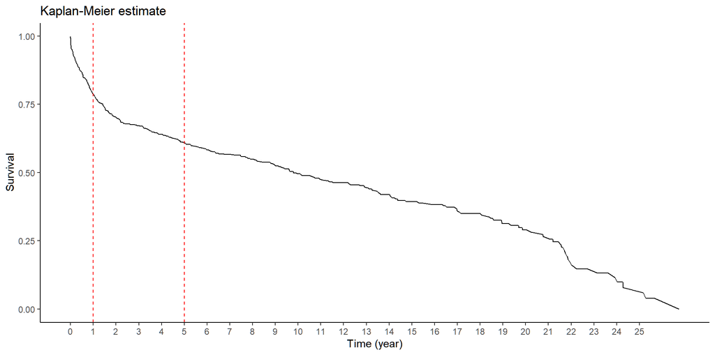

```r
km <- survfit(Surv(raw_data$age, raw_data$dead) ~ 1, conf.type = "log-log")
ggplot() +
  geom_line(aes(x = km$time, y = km$surv)) +
  geom_vline(aes(xintercept = 1), color = "red", linetype = "dashed") +
  geom_vline(aes(xintercept = 5), color = "red", linetype = "dashed") +
  labs(x = expression("Time (year)"), y = expression("Survival"),
       title = "Kaplan-Meier estimate") +
  scale_x_continuous(breaks = seq(0, 25, 1)) +
  theme_classic()
```

## Analysis Process

We conduct four models on three datasets derived from the raw data.

Four models:

- Cox model of survival data versus all the main effects (six adversities)
- Cox model of survival data versus main effects and interaction terms selected by lasso
- Cox model of survival data versus main effects and interaction terms selected by stepwise BIC
- Cox model of survival data versus `adv_mom`, sum of other adversities `adv_other_cumulative` and their interaction term

Three datasets:

- `age_below_1`: Include all the samples. For those whose `age` > 1, use `age` = 1, and `dead` = FALSE
- `age_above_1_below_5`: Include samples of `age` > 1. For those whose `age` > 5, use `age` = 5, and `dead` = FALSE
- `age_above_5`: Include samples of `age` > 5.

Note that for the `age_below_1` dataset, we exclude `adv_sib` from all models.

```r
age_below_1 <- raw_data %>%
  select(starts_with("adv_"), age, dead, -adv_cumulative) %>%
  mutate(dead = if_else(age > 1, FALSE, dead)) %>%
  mutate(age = if_else(age > 1, 1, age))

age_above_1_below_5 <- raw_data %>%
  filter(age >= 1) %>%
  select(starts_with("adv_"), age, dead, -adv_cumulative) %>%
  mutate(dead = if_else(age > 5, FALSE, dead)) %>%
  mutate(age = if_else(age > 5, 5, age))

age_above_5 <- raw_data %>%
  filter(age >= 5) %>%
  select(starts_with("adv_"), age, dead, -adv_cumulative)
```

Below is the summary of three datasets. The number of events refers to the number of uncensored death.

```r
data.frame(
  nobs = c(nrow(age_below_1), nrow(age_above_1_below_5), nrow(age_above_5)),
  nevt = c(sum(age_below_1$dead), sum(age_above_1_below_5$dead), sum(age_above_5$dead))
) %>%
  `row.names<-`(c("Age 1-", "Age 1+, 5-", "Age 5+")) %>%
  kable(row.names = TRUE,
        col.names = c("Number of Samples", "Number of Events")) %>%
  kable_styling(full_width = FALSE, position = "center", font_size = 18)
```

|  | Number of Samples | Number of Events |
| --- | --- | --- |
| Age 1- | 562 | 120 |
| Age 1+, 5- | 440 | 92 |
| Age 5+ | 277 | 110 |

## Cox Model - Main Effects

```r
run_full_model <- function(data, below_one = FALSE) {
  varnames = names(data)[startsWith(names(data), "adv_")]
  if (below_one) {
    varnames = varnames[varnames != "adv_sib"]
  }
  full_formula = paste("Surv(age, dead) ~", paste0(varnames, collapse = "+ "))
  full_model = coxph(
    as.formula(full_formula),
    data = data
  )
  return (full_model)
}
```

### Age below 1

```r
full_age_below_1 <- run_full_model(age_below_1, below_one = TRUE)
summary(full_age_below_1)
```

```
## Call:
## coxph(formula = as.formula(full_formula), data = data)
##
##   n= 562, number of events= 120
##
##                     coef exp(coef) se(coef)      z Pr(>|z|)
## adv_densityTRUE  -0.4879    0.6139   0.2529 -1.929   0.0537 .
## adv_rainTRUE     -0.2429    0.7844   0.3179 -0.764   0.4449
## adv_momTRUE       0.4337    1.5429   0.1946  2.229   0.0258 *
## adv_mom_rankTRUE  0.1504    1.1624   0.2084  0.722   0.4704
## adv_mom_dsiTRUE  -0.1680    0.8453   0.2214 -0.759   0.4480
## ---
## Signif. codes:  0 '***' 0.001 '**' 0.01 '*' 0.05 '.' 0.1 ' ' 1
##
##                  exp(coef) exp(-coef) lower .95 upper .95
## adv_densityTRUE     0.6139     1.6289    0.3740     1.008
## adv_rainTRUE        0.7844     1.2749    0.4206     1.463
## adv_momTRUE         1.5429     0.6481    1.0538     2.259
## adv_mom_rankTRUE    1.1624     0.8603    0.7726     1.749
## adv_mom_dsiTRUE     0.8453     1.1829    0.5477     1.305
##
## Concordance= 0.575  (se = 0.025 )
## Likelihood ratio test= 11.53  on 5 df,   p=0.04
## Wald test            = 11.23  on 5 df,   p=0.05
## Score (logrank) test = 11.43  on 5 df,   p=0.04
```

### Age above 1 and below 5

```r
full_age_above_1_below_5 <- run_full_model(age_above_1_below_5)
summary(full_age_above_1_below_5)
```

```
## Call:
## coxph(formula = as.formula(full_formula), data = data)
##
##   n= 440, number of events= 92
##
##                      coef exp(coef) se(coef)      z Pr(>|z|)
## adv_densityTRUE   0.04178   1.04266  0.24461  0.171 0.864388
## adv_rainTRUE     -0.36927   0.69124  0.33866 -1.090 0.275537
## adv_momTRUE       0.78781   2.19858  0.21648  3.639 0.000274 ***
## adv_sibTRUE      -0.08060   0.92256  0.27909 -0.289 0.772730
## adv_mom_rankTRUE  0.22330   1.25020  0.24313  0.918 0.358394
## adv_mom_dsiTRUE  -0.61402   0.54117  0.27299 -2.249 0.024497 *
## ---
## Signif. codes:  0 '***' 0.001 '**' 0.01 '*' 0.05 '.' 0.1 ' ' 1
##
##                  exp(coef) exp(-coef) lower .95 upper .95
## adv_densityTRUE     1.0427     0.9591    0.6455    1.6841
## adv_rainTRUE        0.6912     1.4467    0.3559    1.3424
## adv_momTRUE         2.1986     0.4548    1.4384    3.3606
## adv_sibTRUE         0.9226     1.0839    0.5339    1.5943
## adv_mom_rankTRUE    1.2502     0.7999    0.7763    2.0134
## adv_mom_dsiTRUE     0.5412     1.8478    0.3169    0.9241
##
## Concordance= 0.619  (se = 0.029 )
## Likelihood ratio test= 18.38  on 6 df,   p=0.005
## Wald test            = 18.7  on 6 df,   p=0.005
## Score (logrank) test = 19.48  on 6 df,   p=0.003
```

### Age above 5

```r
full_age_above_5 <- run_full_model(age_above_5)
summary(full_age_above_5)
```

```
## Call:
## coxph(formula = as.formula(full_formula), data = data)
##
##   n= 277, number of events= 110
##
##                     coef exp(coef) se(coef)      z Pr(>|z|)
## adv_densityTRUE   0.1406    1.1510   0.2672  0.526  0.59864
## adv_rainTRUE     -0.2902    0.7481   0.3099 -0.936  0.34903
## adv_momTRUE       0.7398    2.0956   0.2257  3.278  0.00105 **
## adv_sibTRUE       0.2405    1.2719   0.2469  0.974  0.33003
## adv_mom_rankTRUE  0.2448    1.2773   0.2402  1.019  0.30822
## adv_mom_dsiTRUE  -0.2983    0.7421   0.2320 -1.286  0.19852
## ---
## Signif. codes:  0 '***' 0.001 '**' 0.01 '*' 0.05 '.' 0.1 ' ' 1
##
##                  exp(coef) exp(-coef) lower .95 upper .95
## adv_densityTRUE     1.1510     0.8688    0.6818     1.943
## adv_rainTRUE        0.7481     1.3367    0.4075     1.373
## adv_momTRUE         2.0956     0.4772    1.3464     3.262
## adv_sibTRUE         1.2719     0.7862    0.7839     2.064
## adv_mom_rankTRUE    1.2773     0.7829    0.7977     2.045
## adv_mom_dsiTRUE     0.7421     1.3476    0.4709     1.169
##
## Concordance= 0.616  (se = 0.035 )
## Likelihood ratio test= 13.93  on 6 df,   p=0.03
## Wald test            = 14.83  on 6 df,   p=0.02
## Score (logrank) test = 15.31  on 6 df,   p=0.02
```